# HW3

164693 박주성

2020 4 27

먼저 실행에 앞서 패키지들을 불러옵니다.

```r
library(aplpack)
library(Hotelling)
library(car)
library(onewaytests)
library(heplots)
```

# 1

## 1) 함수 생성

```r
Z_2mean <- function(x1, x2, s1, s2, alpha){
  TS0 <- (mean(x1) - mean(x2))/sqrt(s1^2/length(x1) + s2^2/length(x2))
  P_value <- 2 * (1 - pnorm(abs(TS0)))

  cat("TS0 = ", TS0, ",P_value =", P_value, "\n")
  cat("Under alpha = ", alpha, ",")
  if (P_value > alpha) {cat("fail to reject H0 \n")}
  else {cat("reject H0 \n")}

}
```

## 2) 실행

```r
x1 <- rnorm(150, mean = 5.5, sd = 10)
x2 <- rnorm(200, mean = 10, sd = 50)

Z_2mean(x1, x2, 10, 8, 0.05)
```

```
## TS0 =  -3.967672 ,P_value = 7.257806e-05
## Under alpha =  0.05 ,reject H0
```

```r
x3 <- rnorm(150, mean = 0, sd = 1)
x4 <- rnorm(200, mean = 0.01, sd = 3)

Z_2mean(x3, x4, 1, 3, 0.05)
```

```
## TS0 =  -1.519017 ,P_value = 0.1287582
## Under alpha =  0.05 ,fail to reject H0
```

1번을 풀면서 사용했던 변수들이 영향이 있을 수 있기 때문에 다음과 같은 코드를 실행합니다.

```r
rm(list = ls())
```

# 2

```r
CS <- read.csv("Canine_Species.csv", header = T, sep = ",")
attach(CS)
head(CS)
```

```
##    X1   X2 X3 X4 X5  X6 X7 X8  X9 sex    Species
## 1 123 10.1 23 23 19 7.8 32 33 5.6   1 Modern dog
## 2 137  9.6 19 22 19 7.8 32 40 5.8   1 Modern dog
## 3 121 10.2 18 21 21 7.9 35 38 6.2   1 Modern dog
## 4 130 10.7 24 22 20 7.9 32 37 5.9   1 Modern dog
## 5 149 12.0 25 25 21 8.4 35 43 6.6   1 Modern dog
## 6 125  9.5 23 20 20 7.8 33 37 6.3   1 Modern dog
```

## 1)

1. Test for significant differences between the five species in terms of the mean values and the variation in the nine variables.

```r
result <- manova(as.matrix(CS[, 1:9]) ~ Species)
summary(result) # 가장 로버스트한 Pillai의 방법을 사용합니다.
```

```
##           Df Pillai approx F num Df den Df    Pr(>F)
## Species    4 2.5892   13.662     36    268 < 2.2e-16 ***
## Residuals 72
## ---
## Signif. codes:  0 '***' 0.001 '**' 0.01 '*' 0.05 '.' 0.1 ' ' 1
```

```r
#summary(result, test = "Wilks")
#summary(result, test = "Roy")
#summary(result, test = "Hotelling-Lawley")
```

```r
boxM(CS[, 1:9], matrix(CS[, 11]))
```

```
##
##  Box's M-test for Homogeneity of Covariance Matrices
##
## data:  CS[, 1:9]
## Chi-Sq (approx.) = 263.21, df = 180, p-value = 5.168e-05
```

위의 결과들을 참고한다면 모든 종류의 개들의 평균과 분산이 같다고 말할 순 없을 것 같습니다. 두 코드에서 모두 p-value가 매우 낮은 값을 가졌습니다.

alpha = 0.05 로 놓는다면 두 경우 모두 P-value < alpha 이므로 귀무가설을 기각하게 됩니다.

따라서 종에 따른 평균과 분산은 같다고 말할 수 없습니다.

2. Test both for overall differences and for differences between the prehistoric Thai dogs and each of the other groups singly.

이 문제를 풀기 위해서는 반복문이 필요하고, levels라는 것도 사용하는 것이 용이할 것으로 보입니다. 일단 어떻게 생겼는지 확인하면

```r
levels(Species)
```

```
## [1] "Couns"         "Golden jackal" "Indian wolf"   "Modern dog"
## [5] "Prehistoric"
```

데이터에서 나와있는 순서대로 levels들이 정리되어있지 않기 때문에 정리합니다.

```r
Species <- factor(Species, levels = c("Modern dog", "Golden jackal", "Couns", "Indian wolf", "Prehistoric"))
detach(CS)
CS <- data.frame(CS[, 1:10], Species)
rm(Species) # 영향을 줄 수 있기에 제거합니다.
attach(CS)
levels(Species)
```

```
## [1] "Modern dog"    "Golden jackal" "Couns"         "Indian wolf"
## [5] "Prehistoric"
```

좀 더 나아진 것 같습니다.

```r
for (i in 1:4){
  new <- subset(CS, (Species == levels(Species)[i] | Species == levels(Species)[5]))
  detach(CS)
  attach(new)

  a <- hotelling.test(X1 + X2 + X3 + X4 + X5 + X6 + X7 +X8 + X9 ~ matrix(Species)) # 여기서 왜 matrix를 써야하는지는 잘 모르겠습니다.
  b <- boxM(new[, 1:9], matrix(new[, 11])) # matrix

  cat(levels(Species)[i], "와 Prehistoric의 관계는 \n")
  print(a)
  cat("\n")
  print(b)
  cat("\n\n")

  detach(new)
  attach(CS)
}
```

```
## Modern dog 와 Prehistoric의 관계는
## Test stat:  8.8603
## Numerator df:  9
## Denominator df:  16
## P-value:  0.0001013
##
##
##  Box's M-test for Homogeneity of Covariance Matrices
##
## data:  new[, 1:9]
## Chi-Sq (approx.) = 65.753, df = 45, p-value = 0.0234
##
##
##
## Golden jackal 와 Prehistoric의 관계는
## Test stat:  23.527
## Numerator df:  9
## Denominator df:  20
## P-value:  9.423e-09
##
##
##  Box's M-test for Homogeneity of Covariance Matrices
##
## data:  new[, 1:9]
## Chi-Sq (approx.) = 63.709, df = 45, p-value = 0.03448
##
##
##
## Couns 와 Prehistoric의 관계는
## Test stat:  81.894
## Numerator df:  9
## Denominator df:  17
## P-value:  3.222e-12
##
##
##  Box's M-test for Homogeneity of Covariance Matrices
##
## data:  new[, 1:9]
## Chi-Sq (approx.) = 65.644, df = 45, p-value = 0.02389
##
##
##
## Indian wolf 와 Prehistoric의 관계는
## Test stat:  17.199
## Numerator df:  9
## Denominator df:  14
## P-value:  4.213e-06
##
##
##  Box's M-test for Homogeneity of Covariance Matrices
##
## data:  new[, 1:9]
## Chi-Sq (approx.) = 69.109, df = 45, p-value = 0.01194
```

비교한 결과 모든 p-value 값들이 낮기에 분산과 평균이 같다는 귀무가설을 모두 기각합니다.

하지만 여기서 Modern dog과 Prehistoric의 평균의 비교는 다른 비교들보다 높기에 약간의 가설이 존재할 수 있다고 생각할 수 있습니다.

3. What conclusion do you draw with regard to the similarity between prehistoric Thai dogs and the other groups?

i에서의 결과로 모든 종들이 같지는 않을 것이라는 판단을 할 수 있었고, ii의 결과를 통해서 Prehistoric과의 관계를 알 수 있었습니다.

그 중 ii에서 p-value값들은 대체적으로 다 낮았습니다만 평균의 측면에서 Modern과의 관계에서의 p-value 값이 다른 값들에 비해서 큽니다.

그래서 Prehistoric과 Modern dog이 가장 비슷하다는 가설을 세울 수 있을 것 같습니다.

## 2)

성별로 차이가 있는지를 확인하기 위해선 같은 종에서 비교를 해야합니다. 따라서 다음과 같이 비교합니다.

```r
for (i in 1:4){
  new <- subset(CS, Species == levels(Species)[i])
  detach(CS)
  attach(new)

  a <- hotelling.test(X1 + X2 + X3 + X4 + X5 + X6 + X7 + X8 + X9 ~ matrix(sex))
  cat(levels(Species)[i], "의 성별의 차이에 대한 값은 ")
  print(a)
  cat("\n")

  detach(new)
  attach(CS)
}
```

```
## Modern dog 의 성별의 차이에 대한 값은 Test stat:  1.2685
## Numerator df:  9
## Denominator df:  6
## P-value:  0.3992
##
## Golden jackal 의 성별의 차이에 대한 값은 Test stat:  2.8771
## Numerator df:  9
## Denominator df:  10
## P-value:  0.05757
##
## Couns 의 성별의 차이에 대한 값은 Test stat:  1.7009
## Numerator df:  9
## Denominator df:  7
## P-value:  0.2481
##
## Indian wolf 의 성별의 차이에 대한 값은 Test stat:  6.7941
## Numerator df:  9
## Denominator df:  4
## P-value:  0.04034
```

alpha = 0.05 로 설정되면 Idian wolf를 제외한 종들은 모두 성별로 차이가 없다고 말할 수 있습니다만

alpha = 0.1 로 설정된다면 Golden jackal과 Indian wolf는 성별로 차이가 있다고 말할 수 있습니다.

## 3)

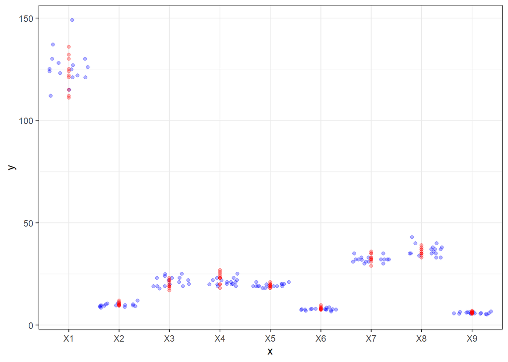

```r
library(ggplot2) #ggplot을 사용하기 위해서 불러옵니다.
new <- subset(CS, Species == "Modern dog")
a <- as.matrix(new[, 1:9])
b <- rep(colnames(a), each = length(rownames(a)))
dim(a) <- c(length(a), 1)

m1 <- data.frame(x = b, y = a)


new <- subset(CS, Species == "Prehistoric")
a <- as.matrix(new[, 1:9])
b <- rep(colnames(a), each = length(rownames(a)))
dim(a) <- c(length(a), 1)

m2 <- data.frame(x = b, y = a)

ggplot() + geom_jitter(data = m1, aes(x = x, y = y), alpha = 0.3, col = 4) +
  geom_point(data = m2, aes(x =x , y = y), alpha = 0.3, col = 2) + theme_bw()
```

위 그림은 각 요인별 산점도를 나타냅니다. 파랑색은 Modern dog이며, 빨간색은 Prehistoric입니다. 두 종 모두가 곂치면 보기 어렵기에 Modern dog 자료를 x축방향으로 흔들어서 보기 쉽게 만들었습니다. 색이 진하게 보인다면 많이 겹쳤다는 것입니다.

대략적인 모습을 확인할 수 있는데, X1에서 Modern dog에서 이상치 같은 값이 하나 있는 것을 제외하곤 상당히 많은 부분이 겹칩니다.

따라서 Modern dog과 Prehistoric이 어느 정도 비슷하다는 생각을 할 수 있습니다.

```r
#변수 초기화
rm(list = ls())
```

# 3

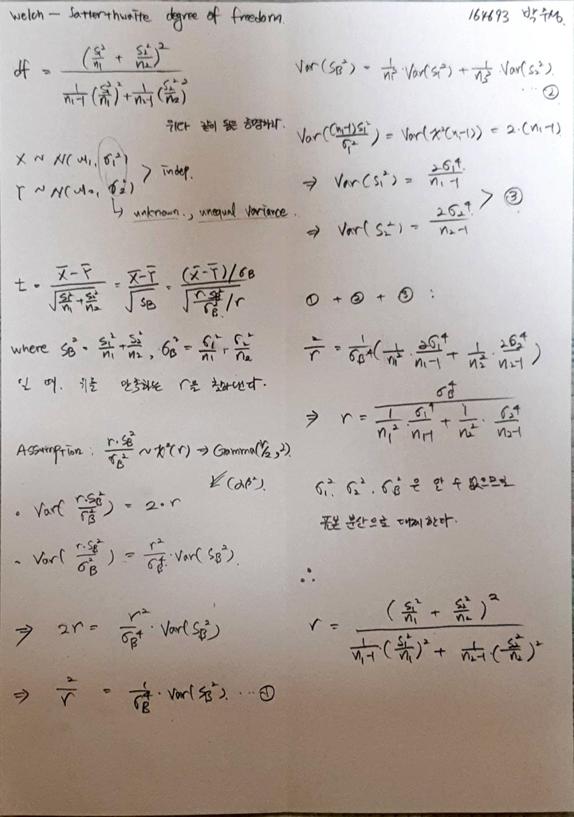

# 4

```r
d1 <- read.csv("Egyptian skulls.csv", header = T, sep = ",")
attach(d1)
```

## 1)

```r
result <- manova(as.matrix(d1[, 2:5]) ~ Period)
summary(result)
```

```
##            Df  Pillai approx F num Df den Df    Pr(>F)
## Period      4 0.35331    3.512     16    580 4.675e-06 ***
## Residuals 145
## ---
## Signif. codes:  0 '***' 0.001 '**' 0.01 '*' 0.05 '.' 0.1 ' ' 1
```

alpha = 0.05 로 놓는다면 P-value < alpha 이기 때문에 귀무가설을 기각하게 됩니다 .

따라서 Period별로 두개골 자료의 평균들은 같다고 말할 수 없습니다.

## 2)

```r
boxM(d1[, 2:5], Period)
```

```
##
##  Box's M-test for Homogeneity of Covariance Matrices
##
## data:  d1[, 2:5]
## Chi-Sq (approx.) = 45.667, df = 40, p-value = 0.2483
```

alpha = 0.05 로 놓는다면 p-value > alpha 이기 때문에 귀무가설을 기각할 수 없습니다.

따라서 Period별 두개골 자료의 분산은 같다고 말할 수 있습니다.